# ジオメトリの移動による日本地図の可視化

沖縄県，北海道の例

[岩田真一郎](https://shinichiro-iwata.github.io/)（ [神奈川大学経済学部](https://www.econ.kanagawa-u.ac.jp/)）

2022-08-17作成，2025-02-26改訂

# 1 目的

日本地図を作成する際に，北海道や沖縄県の位置を変更して表現する場合がある．位置関係は不正確になるが，地図をコンパクトにまとめることができる．最後により少ない`R`コードによる可視化を示す．

- ここでは，`NipponMap`の沖縄県（ジオメトリはポリゴン）の位置を移動して表現．次に，沖縄県の位置の移動に加えて北海道の位置も移動．
  - **注意**：ただし，注意しなければならないのは，移動はコピー＆ペーストによる移動ではなく，ジオメトリ（ここではポリゴン）の緯度経度の変更による移動のため，**沖縄県の形状が変化**．
    - 画像にして，貼り付ける方法は[人口集中地区データによる人口分布の可視化](https://shinichiro-iwata.github.io/geospatial-data-visualization/DID-pop-visualization.html)を参照．

パッケージ：`sf`，`tidyverse`，`Nipponmap`

```r
library(sf)
library(tidyverse)
library(NipponMap)
```

# 2 `geometry`（ポリゴンの座標）の変更

**シェープファイル**

作業フォルダに`jpn.shp`などが含まれる`shapes`と示されるフォルダがあることを前提とする．

- `Nippon_map`と名付け，`read_sf()`でデータを読込．
  - シェープファイルを作業フォルダに移すのが面倒だと思う場合は，`Nippon_map<-`以降のコマンドを`read_sf(system.file("shapes/jpn.shp"), package="NipponMap")`にしても可能．この場合，移す作業は必要ない．
  - `crs="WGS84"`を今回は指定．

```r
Nippon_map <-
  read_sf("shapes/jpn.shp", crs="WGS84")
```

**移動前の日本地図**

日本地図を描写．白地図ではなく，都道府県に色を付ける．

- 統計値を色分けするわけではなく，都道府県名で色分けするため，`aes(fill=name)`を指定．色分けは`viridis`（mako（`G`）色）を指定．
  - 色に対応して凡例が47都道府県分出現して，煩雑になるため，`theme(legend.position="none")`を用いて凡例削除．

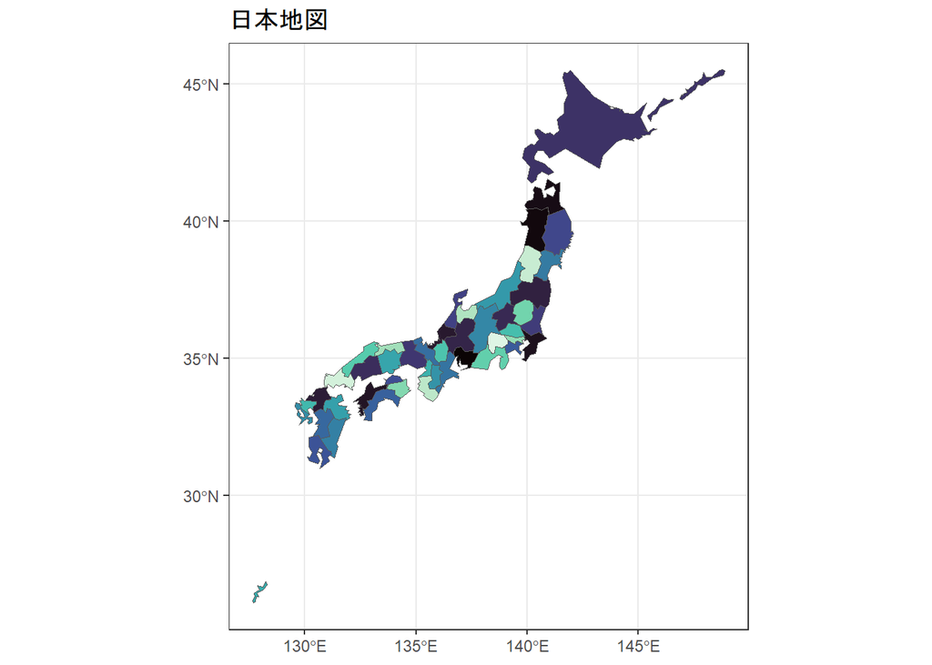

```r
ggplot()+
  geom_sf(data=Nippon_map, aes(fill=name))+
  scale_fill_viridis_d(option="G")+
  ggtitle("日本地図")+
  theme_bw()+
  theme(legend.position="none")
```

**ジオメトリの確認**

`tail()`を用いて下から6行のデータの中身を確認．

- 最終行の6列目が沖縄県のジオメトリ（形状，`geometry`）．

```r
#下から6行のデータの中身
Nippon_map %>%
  tail()
```

| SP_ID | jiscode | name | population | region | geometry |
| --- | --- | --- | --- | --- | --- |
| 42 | 42 | Nagasaki | 1426779 | Kyushu / Okinawa | MULTIPOLYGON (((130.1848 32… |
| 43 | 43 | Kumamoto | 1817426 | Kyushu / Okinawa | MULTIPOLYGON (((130.416 33…. |
| 44 | 44 | Oita | 1196529 | Kyushu / Okinawa | MULTIPOLYGON (((131.5693 32… |
| 45 | 45 | Miyazaki | 1135233 | Kyushu / Okinawa | MULTIPOLYGON (((131.5693 32… |
| 46 | 46 | Kagoshima | 1706242 | Kyushu / Okinawa | MULTIPOLYGON (((130.7114 32… |
| 47 | 47 | Okinawa | 1392818 | Kyushu / Okinawa | MULTIPOLYGON (((127.6461 26… |

沖縄県の形状は（マルチ）ポリゴン．

- 緯度と経度から成る点（ポイント）を結び，ポリゴンが作られる．
  - 例えば，3点から成る三角形の場合は次のように表現される．
  - `緯度1 経度1`の座標から出発し，`緯度2 経度2`，`緯度3 経度3`の座標を通り，`緯度1 経度1`の座標に戻る．

```
POLYGON((緯度1 経度1,緯度2 経度2,緯度3 経度3,緯度1 経度1))
```

**沖縄県の選抜と位置の移動**

沖縄県の位置だけを移動すれば良いため，日本地図から沖縄県のみを抜き出し，沖縄県の位置を移動した地図を作成する．

- `Nippon_map`から`filter()`を用いて，沖縄県（`name=="Okinawa"`）を選抜．オブジェクト名を`Okinawa_map`とする．
- `geometry(POLYGON((...))`の経度，緯度に数値を加えることにより，沖縄県のポリゴンの位置を移動させる．
  - ここでは，ポリゴンを構成する座標を東経方向に4.8°E，北緯方向に14.5°N移動．
  - 地図名は`Okinawa_map1`とする．

```r
#沖縄県の選抜
Nippon_map %>%
  filter(name=="Okinawa") ->
  Okinawa_map

#沖縄県の位置の移動
Okinawa_map %>%
  mutate(geometry=geometry+c(4.8, 14.5)) ->
  Okinawa_map1
```

**表と地図による移動確認**

表で`geometry`が変更されているか確認．

- 移動後の`Okinawa_map1`は`crs`（座標参照系）が付されていない．
  - ここでは，`crs`を`Nippon_map`と揃えるため，EPSG：4326：WGS84を選択（`st_crs(データ名)=EPSG系番号`）．

```r
#表の確認
Okinawa_map1 %>%
  head()
```

| SP_ID | jiscode | name | population | region | geometry |
| --- | --- | --- | --- | --- | --- |
| 47 | 47 | Okinawa | 1392818 | Kyushu / Okinawa | MULTIPOLYGON (((132.4461 40… |

```r
#crs
st_crs(Okinawa_map1)=4326
```

移動前と移動後の地図（Rコードは示さない）を比較．

- **注意**：異なる緯度経度に移動したことによって，ポリゴン（この場合，沖縄県）の**形状が変化**（見た目をまったく変化させないためには，移動前のポリゴンをコピー＆ペーストする方法が考えられる）．

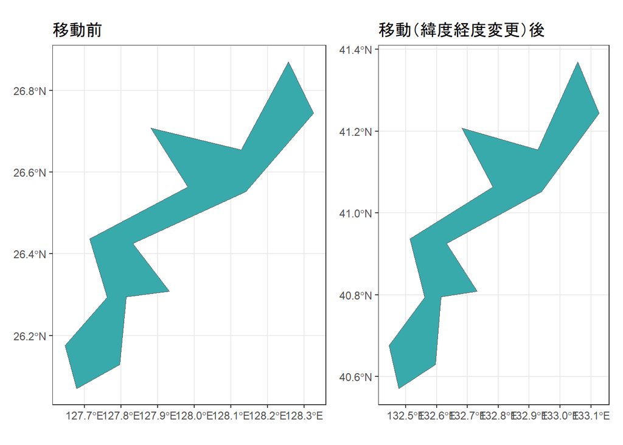

**データの結合**

位置前の沖縄県と位置後の沖縄県を入れ替える．

```r
#移動前の沖縄県を除く日本地図
Nippon_map %>%
  filter(name!="Okinawa") ->
  Nippon_map1

#移動後の沖縄県を加えた日本地図
Nippon_map2 <-
  rbind(Nippon_map1, Okinawa_map1)
```

**完成地図**

沖縄県の位置が移動した地図の可視化．

- 位置を区切る線を引く（`annotate()`）．
  - 線の出発点（座標）と終点を示し，線の色（`color`）や太さ（`linewidth`）を指定．
  - 沖縄の位置が変更したため，誤解を与えないように`theme_void()`を選択し，緯度経度の表記を削除．

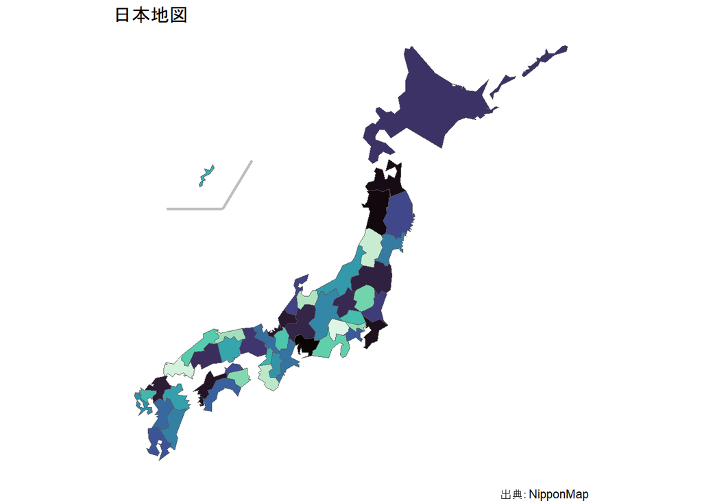

```r
ggplot()+
  geom_sf(data=Nippon_map2, aes(fill=name))+
  scale_fill_viridis_d(option="G")+
  annotate("segment", x=131, xend=133.5,
           y=39.8, yend=39.8,
           color="gray", linewidth=1)+
  annotate("segment", x=133.5, xend=134.8,
           y=39.8, yend=41.5,
           color="gray", linewidth=1)+
  labs(caption="出典：NipponMap")+
  ggtitle("日本地図")+
  theme_void()+
  theme(legend.position="none")
```

# 3 応用

## 3.1 人口分布の可視化

作成した`Nippon_map2`に人口分布を可視化．

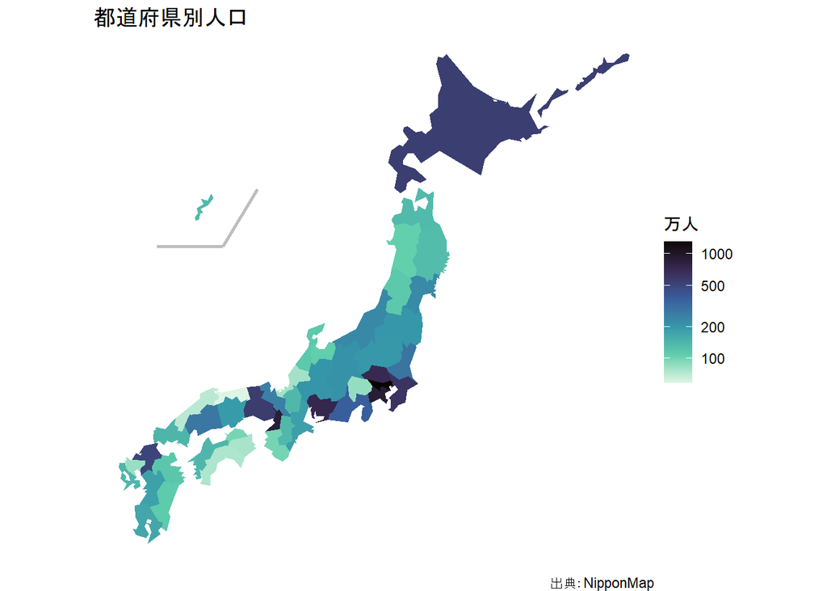

```r
#閾値
my_breaks <- c(100, 200, 500, 1000)

#可視化
ggplot()+
  geom_sf(data=Nippon_map2,
          aes(fill=population/10000,
              color=population/10000))+
  scale_fill_viridis_c(option="G",
                       direction=-1,
                       trans="log10",
                       breaks=my_breaks)+
  scale_color_viridis_c(option="G",
                       direction=-1,
                       trans="log10",
                       breaks=my_breaks)+
  annotate("segment", x=131, xend=133.5,
           y=39.8, yend=39.8,
           color="gray", linewidth=1)+
  annotate("segment", x=133.5, xend=134.8,
           y=39.8, yend=41.5,
           color="gray", linewidth=1)+
  labs(fill="万人", color="万人",
       caption="出典：NipponMap")+
  ggtitle("都道府県別人口")+
  theme_void()
```

## 3.2 北海道と沖縄県を移動した日本地図

**位置移動のためのコード**

```r
#沖縄県の位置の移動
Okinawa_map %>%
  mutate(geometry=geometry+c(12, 5)) ->
  Okinawa_map2

#北海道の選抜
Nippon_map %>%
  filter(name=="Hokkaido") ->
  Hokkaido_map

#北海道の位置の移動
Hokkaido_map %>%
  mutate(geometry=geometry+c(-11, -4)) ->
  Hokkaido_map

#北海道と沖縄県を除いた日本地図
Nippon_map1 %>%
  filter(name!="Hokkaido") ->
  Nippon_map3

#crs
st_crs(Okinawa_map2)=4326
st_crs(Hokkaido_map)=4326

#データの結合
Nippon_map3 <-
  rbind(Hokkaido_map, Nippon_map3) %>%
  rbind(Nippon_map3, Okinawa_map2)
```

**完成地図**

作成した`Nippon_map3`に人口分布を可視化．

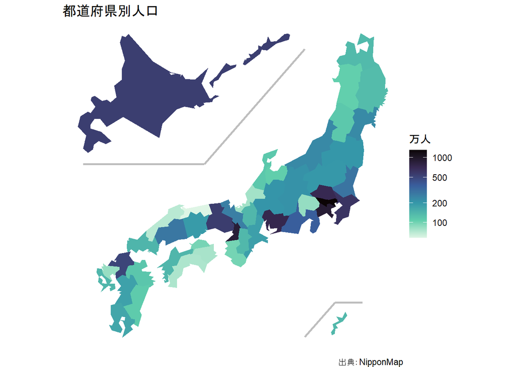

```r
ggplot()+
  geom_sf(data=Nippon_map3,
          aes(fill=population/10000,
              color=population/10000))+
  scale_fill_viridis_c(option="G",
                       direction=-1,
                       trans="log10",
                       breaks=my_breaks)+
  scale_color_viridis_c(option="G",
                       direction=-1,
                       trans="log10",
                       breaks=my_breaks)+
  annotate("segment", x=129, xend=134.2, y=37, yend=37,
            color="gray", linewidth=1)+
  annotate("segment", x=134.2, xend=138.5, y=37, yend=41,
           color="gray", linewidth=1)+
  annotate("segment", x=139.8, xend=141, y=32.2, yend=32.2,
            color="gray", linewidth=1)+
  annotate("segment", x=138.5, xend=139.8, y=31, yend=32.2,
           color="gray", linewidth=1)+
  labs(fill="万人", color="万人",
       caption="出典：NipponMap")+
  ggtitle("都道府県別人口")+
  theme_void()
```

# 4 `replace()`の利用

**ジオメトリの直接変更**

これまで，移動前の北海道・沖縄県の地図を切り抜き，移動後の地図を合併するという手順を踏んだ．最後に当初の`Nippon_map`の北海道・沖縄県のジオメトリを直接変更する，`R`コードのより**少ない**方法を紹介する．

- `replace()`を用いて変更．
  - `replace()`：第1引数に列名（変数名），第2引数に置き換える位置や条件，第3引数に置き換える値を示す．

```
#replaceの使い方

replace(列名, 置き換える位置, 置き換える値)
```

- `[]`：要素の抽出に使う．`geometry[]`で`geometry`列にある要素を抽出．`[]`内に`SP_ID==47`なので，都道府県識別番号（`SP_ID`）が沖縄県（`47`）を満たす`geometry`列の要素を抽出している．

```r
#ジオメトリの変更
Nippon_map <- Nippon_map %>%
  mutate(geometry=replace(
    geometry, SP_ID==1, geometry[SP_ID==1]+c(-11, -4))) %>%
  mutate(geometry=replace(
    geometry, SP_ID==47, geometry[SP_ID==47]+c(12, 5)))
```

**完成地図**

地図は`Nippon_map`のまま（`data=Nippon_map`）．

- 少ない`R`コードで上と同じ地図が完成（色をあえて変更）．

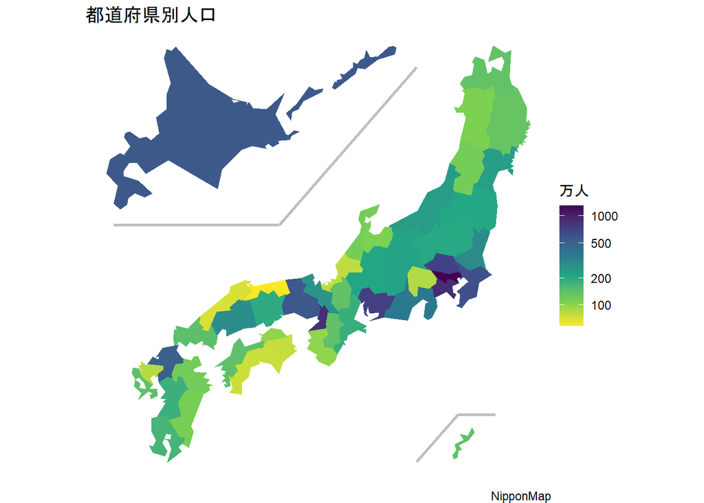

```r
ggplot()+
  geom_sf(data=Nippon_map,
          aes(fill=population/10000,
              color=population/10000))+
  scale_fill_viridis_c(direction=-1,
                       trans="log10",
                       breaks=my_breaks)+
  scale_color_viridis_c(direction=-1,
                       trans="log10",
                       breaks=my_breaks)+
  annotate("segment", x=129, xend=134.2, y=37, yend=37,
            color="gray", linewidth=1)+
  annotate("segment", x=134.2, xend=138.5, y=37, yend=41,
           color="gray", linewidth=1)+
  annotate("segment", x=139.8, xend=141, y=32.2, yend=32.2,
            color="gray", linewidth=1)+
  annotate("segment", x=138.5, xend=139.8, y=31, yend=32.2,
           color="gray", linewidth=1)+
  labs(fill="万人", color="万人",
       caption="NipponMap")+
  ggtitle("都道府県別人口")+
  theme_void()
```

**Rによる地理空間データの可視化**

- チュートリアル[ホーム](https://shinichiro-iwata.github.io/geospatial-data-visualization/)